# Assignment 3 Markdown

March 31st, 2018

The first will display the Hindfoot Length of Male vs. Female for Dipodomys merriami.

Let’s first load the libraries

```r
library(readr)
library(dplyr)
```

And install respective packages making sure to include the cloning path to the GitHub repository

```r
install.packages("dplyr", repos = "https://github.com/mtrousdell/Assignment3_BIO439.git")
install.packages("tidyverse", repos = "https://github.com/mtrousdell/Assignment3_BIO439.git")
```

Now, read in the data and assign to its respective variable for ease of reference.

```r
combined_data <- read_csv('combined.csv')
plots_data <- read_csv('plots.csv')
species_data <- read_csv('species.csv')
surveys_data <- read_csv('surveys.csv')
```

Isolate from the imported data the 3 variables of interest (sex, species_id, hindfootlength) and assign to a variable. Remove any NA’s existing.

```r
Three_variables <- surveys_data[,6:8] %>% filter(!is.na(hindfoot_length)) %>% filter(!is.na(sex))
```

Isolate only the data for Dipodomys merriami.

```r
DM_data <- filter(Three_variables, species_id == 'DM')
```

You can use the simple summary command to get quick stats on your data, just to have an idea of what to expect.

```r
summary(DM_data)
```

[output not shown]

Now that we know some specifics of the data we are dealing with, we shall plot using ggplot. First install the library and package.

```r
install.packages("ggplot2", repos = "https://github.com/mtrousdell/Assignment3_BIO439.git")
library(ggplot2)
```

Start off with the simple aesthetics of a boxplot and assign to a simple variable.

```r
p <- ggplot(data = DM_data, aes(x = sex, y = hindfoot_length)) + geom_boxplot()
```

Add to that variable and spice it up with axis labels and summary data.

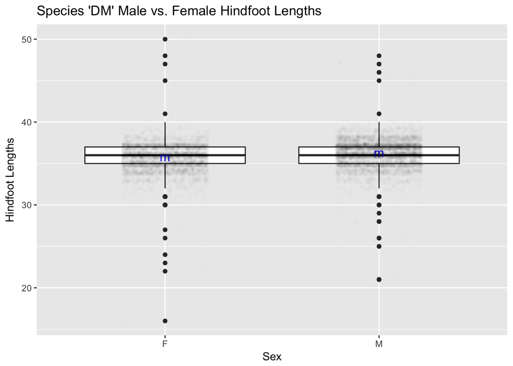

```r
q <- p + ggtitle("Species 'DM' Male vs. Female Hindfoot Lengths") +
  xlab("Sex") + ylab("Hindfoot Lengths")
q + stat_summary(fun.y=mean, geom="point", shape="mean", color="blue", size=4) +
  geom_jitter(shape=16, position=position_jitter(0.2), alpha = .010) +
  scale_shape_manual("", values=c("mean"="x"))
```